# (Exercise 5 - PROG) The Normal distribution does not fit all data

Alumne: *Zixuan Sun*

Grup APA: *13 L*

We are used to assume that data follows the normal distribution, but there are domains where this is obviously incorrect, For instance, problems where variables have a maximum and a minimum value imposed by the nature of the data and where probabilites are skewed towards one of the extremes. In that case we can fit a more suitable distribution. For instance, the **Gumbel** distribution is used specifically for that kind of data. The probability distribution function of the Gumbel distribution is defined as:

$$ p\left(x\right) = \frac{1}{\beta}\ \exp\left(-\ \frac{(x-\mu)}{\beta}\right)\ \exp\left(-\ \exp\left(-\ \frac{(x-\mu)}{\beta}\right)\right) $$

**(a)** Define the *pdf* as a python function and plot the distribution for different parameters.

```python
pip install scikit-learn==0.23
```

```python
# imports
import numpy as np
import matplotlib.pyplot as plt
import seaborn as sns
import pandas as pd
import math
from collections import Counter
from IPython.core.interactiveshell import InteractiveShell
import warnings

# extra imports
from pandas import read_csv
from sklearn.neighbors import KNeighborsClassifier
from sklearn.neighbors import LocalOutlierFactor
from sklearn import preprocessing
from statsmodels.genmod.generalized_linear_model import GLM
from pandas.plotting import scatter_matrix
from scipy.stats import boxcox
```

```python
def gumbel_pdf(x, mu, beta):
    # beta > 0
    return 1/beta*np.exp(-((x-mu)/beta))*np.exp(-(np.exp(-((x-mu)/beta))))
```

```python
x_vals = np.linspace(-5, 10, 2000)

y_vals1 = np.array([gumbel_pdf(x, 0, 0.5) for x in x_vals])

y_vals2 = np.array([gumbel_pdf(x, 0, 1) for x in x_vals])
y_vals3 = np.array([gumbel_pdf(x, 0, 2) for x in x_vals])

y_vals4 = np.array([gumbel_pdf(x, 1, 1) for x in x_vals])
y_vals5 = np.array([gumbel_pdf(x, 2, 2) for x in x_vals])
```

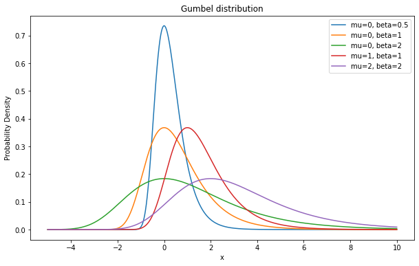

```python
fig, ax = plt.subplots(figsize=(10,6))
ax.plot(x_vals, y_vals1, label='mu=0, beta=0.5')

ax.plot(x_vals, y_vals2, label='mu=0, beta=1')
ax.plot(x_vals, y_vals3, label='mu=0, beta=2')

ax.plot(x_vals, y_vals4, label='mu=1, beta=1')
ax.plot(x_vals, y_vals5, label='mu=2, beta=2')

ax.set_title('Gumbel distribution')
ax.set_xlabel('x')
ax.set_ylabel('Probability Density')
plt.legend()
plt.show()
```

**(b)** Write the negative log likelihood of a sample and find the partial derivatives with respect to the parameters.

Sabem que cada element de la mostra segueix la distribució de Gumbel, llavors la *log-versemblança* amb paràmetres $ \theta = (\mu, \beta)$ és:

\begin{align*} \mathcal{L}(\theta) &= -\ \sum_{n=1}^N\ log\ \ Gumbel(x_n|\theta) = \newline &= -\ \sum_{n=1}^N\ log\ \frac{1}{\beta}\ \exp\left(-\ \frac{(x_n-\mu)}{\beta}\right)\ \exp\left(-\ \exp\left(-\ \frac{(x_n-\mu)}{\beta}\right)\right) = \newline &= -\ \sum_{n=1}^N\ log\ \frac{1}{\beta}\ \exp \left( -\ \frac{(x_n-\mu)}{\beta} -\ \exp\left(-\ \frac{(x_n-\mu)}{\beta}\right) \right)= \newline &= -\ \sum_{n=1}^N\ log\ \frac{1}{\beta}\ -\ \sum_{n=1}^N\ log\ \exp \left( -\ \frac{(x_n-\mu)}{\beta} -\ \exp\left(-\ \frac{(x_n-\mu)}{\beta}\right) \right) = \newline &= -\ \sum_{n=1}^N\ log\ \frac{1}{\beta}\ +\ \sum_{n=1}^N\ \left( \frac{(x_n-\mu)}{\beta} +\ \exp\left(-\ \frac{(x_n-\mu)}{\beta}\right) \right) = \newline &= -\ \sum_{n=1}^N\ ( log\ 1 - log\ \beta ) +\ \sum_{n=1}^N\ \left( \frac{(x_n-\mu)}{\beta} +\ \exp\left(-\ \frac{(x_n-\mu)}{\beta}\right) \right) = \newline &= \sum_{n=1}^N\ log\ \beta +\ \sum_{n=1}^N\ \left( \frac{(x_n-\mu)}{\beta} +\ \exp\left(-\ \frac{(x_n-\mu)}{\beta}\right) \right) = \newline &= N\ log\ \beta +\ \sum_{n=1}^N\ \left( \frac{(x_n-\mu)}{\beta} +\ \exp\left(-\ \frac{(x_n-\mu)}{\beta}\right) \right) = \newline &= N\ log\ \beta +\ \sum_{n=1}^N\ \frac{(x_n-\mu)}{\beta} -\ \sum_{n=1}^N\ \exp\left(\frac{(x_n-\mu)}{\beta}\right) = \newline &= N\ log\ \beta +\ \frac{1}{\beta} \sum_{n=1}^N\ x_n -\frac{N \mu}{\beta} -\ \sum_{n=1}^N\ \exp\left(\frac{(x_n-\mu)}{\beta}\right) \newline \end{align*}

Les derivades parcials són:

(I) \begin{align*} \frac{\partial\mathcal{L}}{\partial\mu} &= \frac{\partial}{\partial\mu} \left( N\ log\ \beta +\ \frac{1}{\beta} \sum_{n=1}^N\ x_n -\frac{N \mu}{\beta} -\ \sum_{n=1}^N\ \exp\left(\frac{(x_n-\mu)}{\beta}\right) \right) = \newline &= - \frac{N}{\beta}\ - \frac{\partial}{\partial\mu}\left( \sum_{n=1}^N\ \exp\left(\frac{(x_n-\mu)}{\beta}\right) \right) \end{align*}

(II) \begin{align*} \frac{\partial\mathcal{L}}{\partial\beta} &= \frac{\partial}{\partial\beta} \left( N\ log\ \beta +\ \frac{1}{\beta} \sum_{n=1}^N\ x_n -\frac{N \mu}{\beta} -\ \sum_{n=1}^N\ \exp\left(\frac{(x_n-\mu)}{\beta}\right) \right) = \newline &= \frac{N}{\beta} -\ \frac{1}{\beta^2} \sum_{n=1}^N\ x_n +\ \frac{N\mu}{\beta^2} - \frac{\partial}{\partial\beta}\left( \sum_{n=1}^N\ \exp\left(\frac{(x_n-\mu)}{\beta}\right) \right) \end{align*}

(c) The partial derivatives result in a system of non linear equations that have to be solved numerically. For the same price we can fit directly the parameters of the distribution using numerical optimization. We are going to use the function that the *scipy* library provides for non linear function minimization (*scipy.optimize.minimize*) that optimizes a function that receives a vector of parameters, in this case we want to minimize the negative log likelihood that will be a function of the two parameters ($\mu,\beta$). The optimization method that you must use is **Nelder-Mead**. You will have to define a python function for the negative log likelihood that receives a vector with the parameters and the data sample.

We are going to apply it to the dataset *California Housing* that can be downloaded using the function *fetch_california_housing* from the *scikit-learn* library. If you plot the variables you will see that there are several variables that behave like the Gumbel distribution. Pick two of these variables and use the minimization function to fit the negative log likelihood of the Gumbel distribution to the data of these variables.

```python
def negative_loglikelihood(popt, X):
    # parameters
    mu   = popt[0]
    beta = popt[1]

    gumbel = 1/beta * np.exp(-(X*mu)/beta) * np.exp(-1*np.exp(-(X*mu)/beta))
    negL = -1 * np.sum(np.log(gumbel))
    return negL
```

```python
from sklearn.datasets import fetch_california_housing

Xdata = fetch_california_housing(as_frame=True)
```

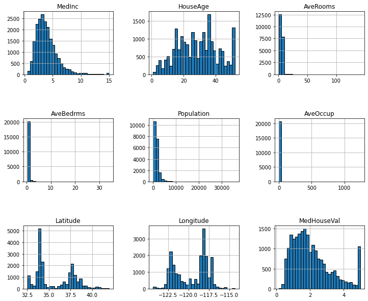

```python
Xdata.frame.hist(figsize=(12, 10), bins=30, edgecolor="black")
plt.subplots_adjust(hspace=0.7, wspace=0.4)
```

```python
Xdata.frame.info();
```

```
<class 'pandas.core.frame.DataFrame'>
RangeIndex: 20640 entries, 0 to 20639
Data columns (total 9 columns):
 #   Column       Non-Null Count  Dtype
---  ------       --------------  -----
 0   MedInc       20640 non-null  float64
 1   HouseAge     20640 non-null  float64
 2   AveRooms     20640 non-null  float64
 3   AveBedrms    20640 non-null  float64
 4   Population   20640 non-null  float64
 5   AveOccup     20640 non-null  float64
 6   Latitude     20640 non-null  float64
 7   Longitude    20640 non-null  float64
 8   MedHouseVal  20640 non-null  float64
dtypes: float64(9)
memory usage: 1.4 MB
```

```python
# Escollim les variables 'MedInc' i 'MedHouseVal'
features_of_interest = ['MedInc', 'MedHouseVal']
Xdata1 = Xdata.frame[features_of_interest[0]]
Xdata2 = Xdata.frame[features_of_interest[1]]
X.info()
```

[output not shown]

```python
Xdata1.describe()
```

```
count    20640.000000
mean         3.870671
std          1.899822
min          0.499900
25%          2.563400
50%          3.534800
75%          4.743250
max         15.000100
Name: MedInc, dtype: float64
```

```python
Xdata2.describe()
```

```
count    20640.000000
mean         2.068558
std          1.153956
min          0.149990
25%          1.196000
50%          1.797000
75%          2.647250
max          5.000010
Name: MedHouseVal, dtype: float64
```

```python
from scipy.optimize import minimize

res1 = minimize(negative_loglikelihood, [3, 1], method='nelder-mead', args = (Xdata1))
print(res1)
print('\n')
res2 = minimize(negative_loglikelihood, [1.8, 1], method='nelder-mead', args = (Xdata2))
print(res2)
```

```
 final_simplex: (array([[ 0.0728508 , -0.22371769],
       [ 0.07286306, -0.22375747],
       [ 0.07285843, -0.22377888]]), array([-0., -0., -0.]))
           fun: -0.0
       message: 'Optimization terminated successfully.'
          nfev: 98
           nit: 37
        status: 0
       success: True
             x: array([ 0.0728508 , -0.22371769])


 final_simplex: (array([[-0.06156738, -0.0265564 ],
       [-0.06160703, -0.02661254],
       [-0.06159552, -0.02665037]]), array([-0., -0., -0.]))
           fun: -0.0
       message: 'Optimization terminated successfully.'
          nfev: 89
           nit: 34
        status: 0
       success: True
             x: array([-0.06156738, -0.0265564 ])
```

(d) Plot the Gumbel distribution for the fitted parameters against the normalized histogram ofthe data. Does the parameters fit well the data?

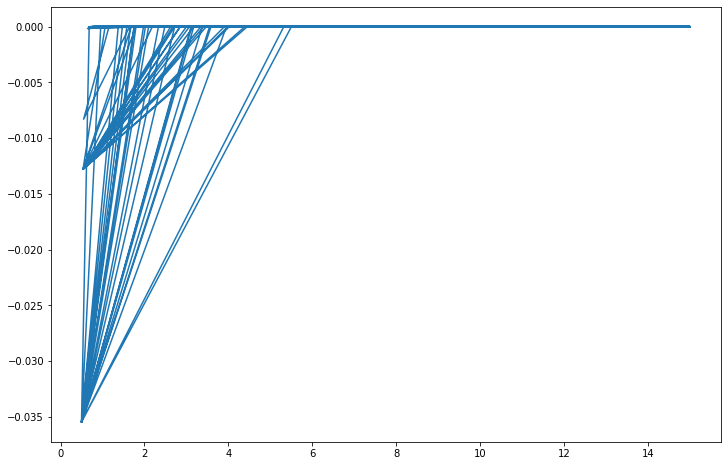

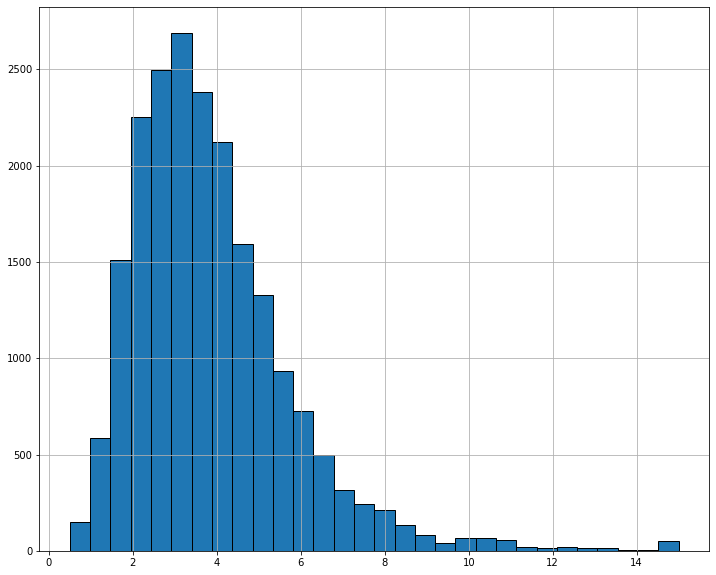

```python
y_real1 = np.array([gumbel_pdf(x, res1.x[0], res1.x[1]) for x in Xdata1])

fig, ax = plt.subplots(figsize=(12,8))
ax.plot(Xdata1, y_real1)

plt.show()

Xdata1.hist(figsize=(12, 10), bins=30, edgecolor="black")
```

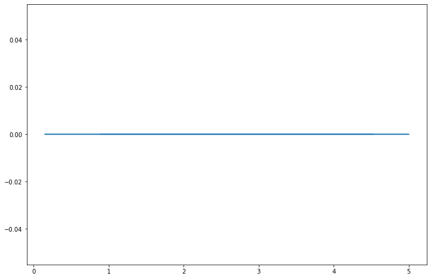

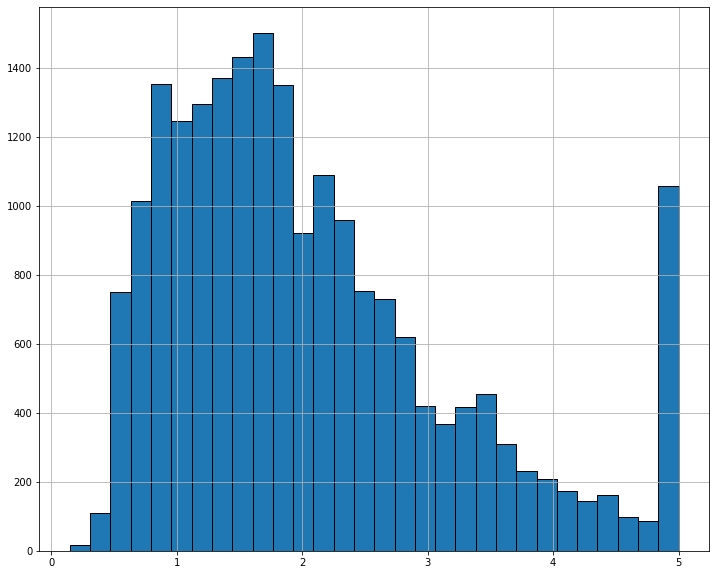

```python
y_real2 = np.array([gumbel_pdf(x, res2.x[0], res2.x[1]) for x in Xdata2])

fig, ax = plt.subplots(figsize=(12,8))
ax.plot(Xdata2, y_real2)

plt.show()

Xdata2.hist(figsize=(12, 10), bins=30, edgecolor="black")
```

No, no encaixa la distrució de Gumbel amb els paràmatres trobats $(\mu, \beta)$ amb les dades reals. He comès algún error però, sincerament no he sapigut trobar-ho.

(e) Now compute the mean and variance of the variables assuming that they are gaussian and compute the probability that the pdf of the Gaussian and the Gumbel distributions assigns to a sample of the data (you can use the function *scipy.stats.norm.pdf* for the gaussian). Is there a large difference on the probabilities?